# Homework Assignment 1

Sam Fang (8114613)

01/30/2021

Q1: (a) The predictor variable is the population. The response variable is the number of confirmed COVID-19 cases.

2. Since $\hat{\beta_1} = \frac{{\sum\limits_{i = 1}^n {({x_i} - \bar x)({y_i}} - \bar y{)}}}{{\sum\limits_{i = 1}^n {{{({x_i} - \bar x)}^2}} }}$ and $\hat{\beta_0} = \bar y - \hat{\beta_1}*\bar x$,we can calculate that $\hat{\beta_0}$ = 2.85395 and $\hat{\beta_1}$= 0.07236.

```r
cov.data <- data.frame(row.names = c("San Bernardino County", "Riverside County",
    "Orange County", "San Diego County", "Santa Clara County", "Kern County", "Sacramento County",
    "Fresno County", "Alameda County"))
cov.data$population <- c(2149, 2411, 3168, 3316, 1927, 887, 1525, 985, 1657)
cov.data$confirmed <- c(251, 239, 223, 212, 93, 85, 79, 81, 67)
x <- cov.data$population
y <- cov.data$confirmed

betaone <- ((x[1] - mean(x)) * (y[1] - mean(y)) + (x[2] - mean(x)) * (y[2] - mean(y)) +
    (x[3] - mean(x)) * (y[3] - mean(y)) + (x[4] - mean(x)) * (y[4] - mean(y)) + (x[5] -
    mean(x)) * (y[5] - mean(y)) + (x[6] - mean(x)) * (y[6] - mean(y)) + (x[7] - mean(x)) *
    (y[7] - mean(y)) + (x[8] - mean(x)) * (y[8] - mean(y)) + (x[9] - mean(x)) * (y[9] -
    mean(y)))/((x[1] - mean(x))^2 + (x[2] - mean(x))^2 + (x[3] - mean(x))^2 + (x[4] -
    mean(x))^2 + (x[5] - mean(x))^2 + (x[6] - mean(x))^2 + (x[7] - mean(x))^2 + (x[8] -
    mean(x))^2 + (x[9] - mean(x))^2)

betazero <- mean(y) - betaone * mean(x)

betaone
```

```
## [1] 0.07236
```

```r
betazero
```

```
## [1] 2.854
```

(c)$\hat{\beta_1}$ is the average change of people confirmed for every 1000 increase in population. $\hat{\beta_0}$ is the number of confirmed people when population is zero.

4. Simple linear regression model: y = 2.854 + 0.07236*x
5. When x = 1000000, y = 72364

```r
predicted <- betazero + 1e+06 * betaone
predicted
```

```
## [1] 72364
```

Q2

```r
trees
```

| Girth | Height | Volume |
| --- | --- | --- |
| 8.3 | 70 | 10.3 |
| 8.6 | 65 | 10.3 |
| 8.8 | 63 | 10.2 |
| 10.5 | 72 | 16.4 |
| 10.7 | 81 | 18.8 |
| 10.8 | 83 | 19.7 |
| 11.0 | 66 | 15.6 |
| 11.0 | 75 | 18.2 |
| 11.1 | 80 | 22.6 |
| 11.2 | 75 | 19.9 |

[output cut: 21 more lines]

1. There are 31 rows and 3 columns in the dataset “trees”. The variable names are “Girth”, “Height” and “Volume”.
2. Here is the scatterplot:

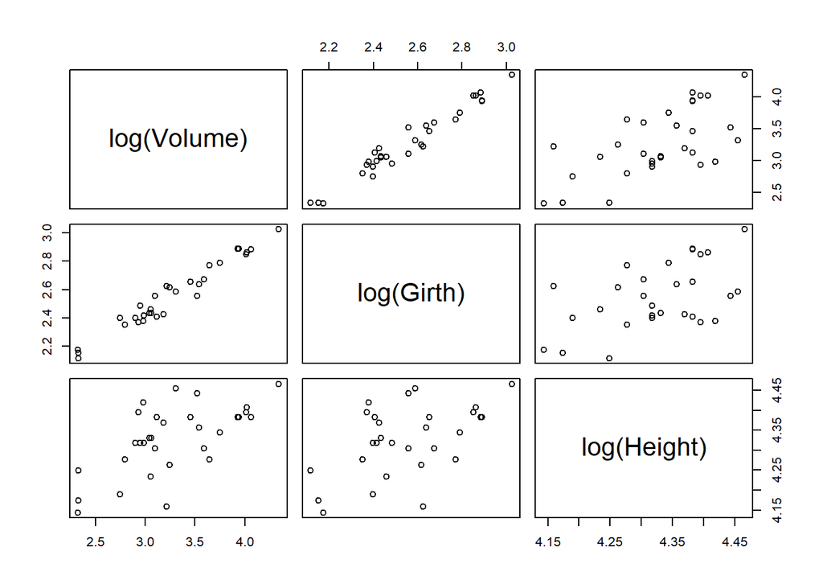

```r
pairs(formula = log(Volume) ~ log(Girth) + log(Height), data = trees)
```

```r
cor(log(trees), method = c("pearson", "kendall", "spearman"))
```

```
##         Girth Height Volume
## Girth  1.0000 0.5302 0.9767
## Height 0.5302 1.0000 0.6486
## Volume 0.9767 0.6486 1.0000
```

4. No, there are no missing values.

```r
is.na(cor(log(trees)))
```

```
##        Girth Height Volume
## Girth  FALSE  FALSE  FALSE
## Height FALSE  FALSE  FALSE
## Volume FALSE  FALSE  FALSE
```

```r
mod <- lm(log(Volume) ~ log(Girth) + log(Height), data = trees)
summary(mod)
```

```
##
## Call:
## lm(formula = log(Volume) ~ log(Girth) + log(Height), data = trees)
##
## Residuals:
##      Min       1Q   Median       3Q      Max
## -0.16856 -0.04849  0.00243  0.06364  0.12922
##
## Coefficients:
##             Estimate Std. Error t value Pr(>|t|)
## (Intercept)   -6.632      0.800   -8.29  5.1e-09 ***
## log(Girth)     1.983      0.075   26.43  < 2e-16 ***
## log(Height)    1.117      0.204    5.46  7.8e-06 ***
## ---
## Signif. codes:  0 '***' 0.001 '**' 0.01 '*' 0.05 '.' 0.1 ' ' 1
##
## Residual standard error: 0.0814 on 28 degrees of freedom
## Multiple R-squared:  0.978,  Adjusted R-squared:  0.976
## F-statistic:  613 on 2 and 28 DF,  p-value: <2e-16
```

```r
mod$coefficients
```

```
## (Intercept)  log(Girth) log(Height)
##      -6.632       1.983       1.117
```

```r
X = model.matrix(mod)
Y = log(trees)$Volume
(beta_hat = solve(t(X) %*% X) %*% t(X) %*% Y)
```

```
##               [,1]
## (Intercept) -6.632
## log(Girth)   1.983
## log(Height)  1.117
```

These two results are the same above.

```r
hat_y <- X %*% beta_hat
head(hat_y)
```

```
##    [,1]
## 1 2.310
## 2 2.298
## 3 2.309
## 4 2.808
## 5 2.977
## 6 3.023
```

```r
head(mod$residuals)
```

```
##        1        2        3        4        5        6
##  0.02187  0.03426  0.01384 -0.01062 -0.04303 -0.04196
```

```r
head((t(mod$residuals) %*% mod$residuals/28))
```

```
##          [,1]
## [1,] 0.006624
```

Q3 The procedure is below:
$${\rm{SS}}R = {\sum\limits_{i = 1}^n {({y_i} - {\beta _0} - {\beta _1}{x_i})} ^2}$$

The derivative of SSR with respect to $\beta_0$ is
$$\frac{d}{{d{{\hat \beta }_0}}}\sum\limits_{i = 1}^n {{{({y_i} - {\beta _0} - {\beta _1}{x_i})}^2}} = - 2\sum\limits_{i = 1}^n {({y_i} - {\beta _0} - {\beta _1}{x_i})} = - 2\sum\limits_{i = 1}^n {{y_i} + 2n{\beta _0} + 2{\beta _1}\sum\limits_{i = 1}^n {{x_i}} } = - 2n\bar y + 2n{\hat \beta _0} + 2n{\hat \beta _1}\bar x$$
Set this derivative = 0, we can get
$$- 2n\bar y + 2n{\hat \beta _0} + 2n{\hat \beta _1}\bar x=0.$$
So
$$\hat{\beta_0} = \bar y - \hat{\beta_1}*\bar x$$
The derivative of SSR with respect to $\beta_1$ is
$$\frac{d}{{d{{\hat \beta }_1}}}\sum\limits_{i = 1}^n {{{({y_i} - {\beta _0} - {\beta _1}{x_i})}^2}} = - 2{x_i}\sum\limits_{i = 1}^n {({y_i} - } {\hat \beta _0} - {\hat \beta _1}{x_i}) = - 2\sum\limits_{i = 1}^n {{x_i}{y_i} + 2{{\hat \beta }_0}\sum\limits_{i = 1}^n {{x_i}} } + 2{\hat \beta _1}\sum\limits_{i = 1}^n {{x_i}^2}$$
Set this derivative = 0, we can get
$$- 2\sum\limits_{i = 1}^n {{x_i}{y_i} + 2{{\hat \beta }_0}\sum\limits_{i = 1}^n {{x_i}} } + 2{\hat \beta _1}\sum\limits_{i = 1}^n {{x_i}^2} = 0.$$
So
$$- \sum\limits_{i = 1}^n {{x_i}{y_i} + (\bar y - \hat {{\beta _1}}\bar x)\sum\limits_{i = 1}^n {{x_i}} } + {\hat \beta _1}\sum\limits_{i = 1}^n {{x_i}^2} = 0$$
$${\hat \beta _1} = \frac{{{\rm{\bar y}}\sum\limits_{i = 1}^n {{x_i}} - \sum\limits_{i = 1}^n {{x_i}{y_i}} }}{{\bar x\sum\limits_{i = 1}^n {{x_i} - \sum\limits_{i = 1}^n {x_i^2} } }} = \frac{{n\bar x{\rm{\bar y}} - \sum\limits_{i = 1}^n {{x_i}{y_i}} }}{{n{{\bar x}^2} - \sum\limits_{i = 1}^n {x_i^2} }} = \frac{{\sum\limits_{i = 1}^n {({x_i} - \bar x)({y_i}} - \bar y{)}}}{{\sum\limits_{i = 1}^n {{{({x_i} - \bar x)}^2}} }}$$
Proved